# Functional Prototype Demonstration 1

Team Epsilon-Greedy Quants  
Michael Lee, Nikat Patel, Jose Antonio Alatorre Sanchez

## What we did in this milestone?

We implemented the Policy Gradient algorithm REINFORCE. To test the performance and efficacy, we evaluated it using simulated data.

## Presentation Overview

- REINFORCE Summary
- REINFORCE Implementation
- Performance Metrics
- Version Control Repository
- Next Steps

## REINFORCE Summary

#### Policy Gradient Method

- Estimates Policy directly, not from Action-Value function
- Continuous action space

#### REINFORCE

- Relies on estimated return by Monte-Carlo method
- Uses episode samples to update policy parameter $\theta$

#### REINFORCE Algorithm Steps

**Steps:**

- Initialize the policy parameter $\theta$ at random.
- Generate one episode using policy $\pi_{\theta}: S_1,A_1,R_2,S_2,A_2,…,S_T$.
- For t=1, 2, … , T:
  - Estimate the the return $G_t$
  - Update policy parameters: $\theta←\theta+\alpha\gamma_t G_t \nabla ln \pi(A_t|S_t,\theta)$
    - $\alpha$ - stepsize
    - $\gamma$ - discount factor
    - $G_t$ - cumulative return
    - $\nabla ln \pi(A_t|S_t,\theta)$ - eligibility vector: gradient of the probability of taking action $A_t$ given a state $S_t$ and policy $\pi_{\theta}$

## Challenge: n-asset dimensional action space parametrization.

Our action space is has dimension $n$ where $n$ correponds to the number of assets in our portfolio. To parametrize our policy we followed the standard solution in the univariate case; creation a Gaussian Policy

### Gaussian Policy

$$ \pi(a |s,\boldsymbol\theta):=\frac{1}{\sigma(s,\boldsymbol\theta)\sqrt{2\pi}}exp(-\frac{(a-\mu(s,\boldsymbol\theta))^2}{2\sigma(s,\boldsymbol\theta)^2}) $$

#### Linear Parametrization

$$ \theta:=[\boldsymbol{\theta_{\mu}},\boldsymbol{\theta_{\sigma}}] $$$$ \mu(s,\boldsymbol\theta) :=\boldsymbol{\theta_{\mu}}^T \pmb{x}(s) $$$$ \sigma(s,\boldsymbol\theta) :=exp(\boldsymbol{\theta_{\sigma}}^T \pmb{x}(s)) $$

#### Gradients

$$ \nabla ln\pi(a|s,\boldsymbol\theta_\mu)=\frac{1}{\sigma(s,\boldsymbol\theta)^2}(a-\mu(s,\boldsymbol\theta))\pmb{x}(s) $$$$ \nabla ln\pi(a|s,\boldsymbol\theta_\sigma)=\left(\frac{(a-\mu(s,\boldsymbol\theta))^2}{\sigma(s,\boldsymbol\theta)^2} -1\right)\pmb{x}(s) $$

**The challenge with the multivariate case is that we will need to parametrize the coviariance matrix as well.**

- An increase of $\frac{n*n}{2}$ may not be that much.
- If we account for the interaction of asset features (especialy if we use lags) then the number of parameters grows multiplicatively: $\frac{n*n*features}{2}$

**Solution:** We decided to use uncorrelated parametrizations.

- Set the covariance of each individual action in the policy to 0.
- Calculated the mighty gradients for the multivariate case.

## Multivariate Case

We have a continuous multivariate case parametrized in the following way:

$$ \pi(a|s,\theta)=\frac{exp\left(\frac{1}{2}(a-\mu(s,\Theta_\mu))^T\Sigma(s,\theta_\Sigma)^{-1}(a-\mu(s,\Theta_\mu))\right)}{\sqrt{(2\pi)^k|\Sigma(s,\theta_\Sigma)|}} $$

Where

$$ \mu(s,\Theta_\mu)=\Theta f $$

The parametrization of $\Sigma$ (covariance matrix) will be defined as:

$$ \Sigma{i,j}=\sum_k^m \theta^{\sigma}_{i,j,k}f_k $$

$f=[f_1,...,f_m]$ is the vector of $m$ features and $\Theta$ is a row matrix $\theta_i^T=[\theta_{i,1}...\theta_{i,n}]$ . Hence each of the individual means is a linear combination of the features.

Therefore to calculuate the log gradient we need to use Matrix Calculus. first, we define

$$ u=\Theta f $$

then we can rewrite

$$ ln(\pi(a|s,\theta))=\frac{1}{2}(a-u)^T\Sigma(s,\theta_\Sigma)^{-1}(a-u) -ln(\sqrt{(2\pi)^k|\Sigma(s,\theta_\Sigma)|}) $$

By equation [137] from http://www.math.uwaterloo.ca/~hwolkowi//matrixcookbook.pdf $$ \nabla ln(\pi(a|s,\theta_{i,k}^\mu))=Tr[\frac{\partial g(u)}{\partial u}^T \frac{\partial u}{\partial \theta_{i,k}^\mu }] $$

And then by equation [86] http://www.math.uwaterloo.ca/~hwolkowi//matrixcookbook.pdf

$$ \nabla ln(\pi(a|s,\theta_{i,k}^\mu))=Tr[(\Sigma^{-1}(a-\Theta f))^T I[i]*f_k] $$

Where $I[i]$ is a row vector with zeros in all rows and 1 in row $i$ This can expressed as

$$ \nabla ln(\pi(a|s,\theta_{i,k}^\mu))=\text{row}_i[\Sigma^{-1}(a-\Theta f)] * f_k $$

For the case of $\Sigma$ we can also follow https://stats.stackexchange.com/questions/27436/how-to-take-derivative-of-multivariate-normal-density and apply the chain rule to obtain

$$ \nabla ln(\pi(a|s,\theta_{i,j,k}^\sigma))=Tr\left[[-\frac{1}{2}(\Sigma^{-1}-\Sigma^{-1}(a-\mu(s,\Theta_\mu))(a-\mu(s,\Theta_\mu))^T \Sigma^{-1}]^T I[i=i,j=j]*f_k\right] $$

## Evaluations

To evaluate the REINFORCE algorithm we tried three different rewards functions:

- Maximum return: The Agent receives a reward on each step equals to the return of the portfolio on 1-step
- Maximum Sharpe: The Agent receives 0 as reward on each step until the end of an episode when the agent receives the Sharpe ratio.
- Minimum volatility: The Agent receives 0 as reward on each step until the end of an episode when the agent receives the negative of the volatility of the portfolio.

At each step, the Agent observes the state that equals the previous weights in the portfolio and the last 32 log returns of each asset.

Below we will present the case of minimum volatility as an example. The results were pretty similar for the other reward functions.

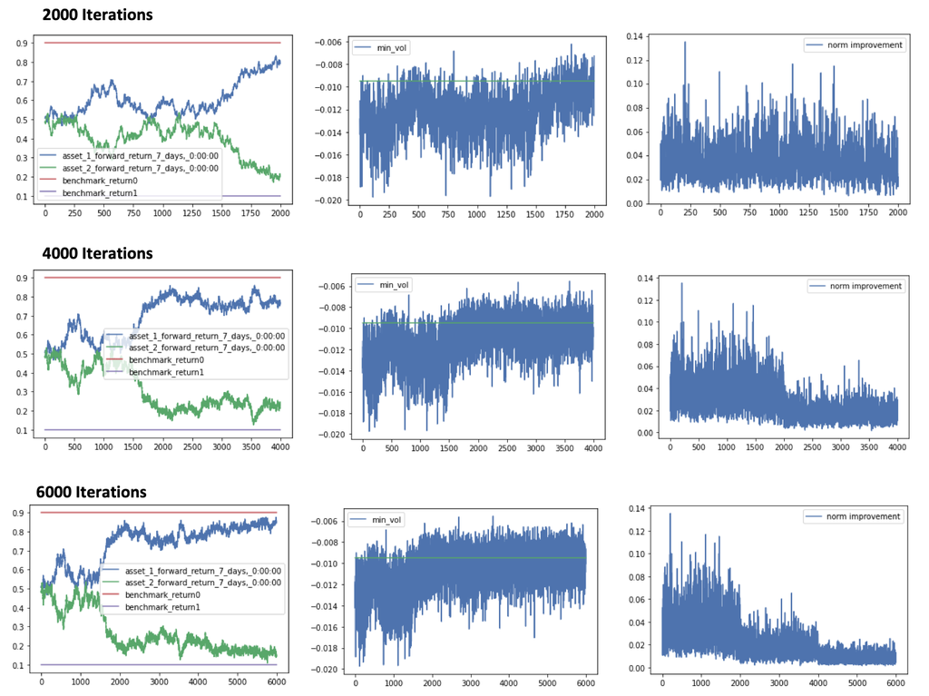

```python
Image(filename='results_1.png')
```

## Results

### The Good

- REINFORCE Converges to the expected portfolio using different reward functions.
- REINFORCE Convergence is agnostic of estimation of a covariance matrix.
- REINFORCE Can allow us easily to add extra features to the parametrization of our function ( technical indicators, sentiment indices, etc)
- REINFORCE finds the optimal policy even when the rewards its stochastic.

### The Bad

- The speed of convergence is pretty slow. it took around 10+ minutes for convergence. This was expected as REINFORCE algorithm is known for having a high variance.
- The convergence was achieved by comparing the results with the expected answer. However the L2 Norm of the parametrization vectors continues to bounce even after convergence. model overfit?.
- The convergence seem to requiry a dynamic $\alpha$ to avoid bouncing out of an optimal result.
- Naive implementation of SGD cant be paralelized.

## Results

### The Ugly

- REINFORCE is an on-policy method. This means that is sample-inefficient as we cannot use episodes generated by old policies. How can we prove that if the market is action independent then we can reuse episodes?

## Performance Metrics

- In our Benchmarks and Benchmark Utility scripts, we have multiple methods established that we will use in the future to gauge our models performance.

```
def compute_daily_returns(asset_prices):
    ...
def compute_covariance_matrix(returns):
    ...
def compute_expected_portfolio_variance(cov_matrix, weights):
    ...
def compute_expected_portfolio_volatility(portfolio_variance):
    ...
def compute_annual_return(returns, weights):
    ...
def get_normalized_returns(asset_prices):
    ...
def compute_sharpe_ratio(asset_allocation):
    ...
def compute_annualized_sharpe_ratio(asset_allocation):
    ...
def compute_rolling_sharpe_ratio(asset_allocation, window=30):
    ...
def compute_rolling_returns(asset_allocation, returns_type, window=30):
    ...
def compute_rolling_volatility(asset_allocation, window=30):
    ...
```

## Version Control Repository

- We have created a private GitHub repository that contains all our data, documentations, code, and notebooks.
- We use version control to develop, update, and collaborate our work.

```
├── data
│   ├── ACWF_ETF__AMEX_1m
│   ├── EEMV_ETF__AMEX_1m
│   ├── EFAV_ETF__AMEX_1m
│   ├── IAU_ETF__AMEX_1m
│   ├── IEF_ETF__NASDAQ_1m
│   ├── IMTM_ETF__AMEX_1m
│   ├── IQLT_ETF__AMEX_1m
│   ├── IVLU_ETF__AMEX_1m
│   ├── LQD_ETF__AMEX_1m
│   ├── MTUM_ETF__AMEX_1m
│   ├── QUAL_ETF__AMEX_1m
│   ├── USMV_ETF__AMEX_1m
│   ├── UUP_ETF__AMEX_1m
│   ├── VLUE_ETF__AMEX_1m
├── data_env
│   ├── ief.parquet
│   └── spy.parquet
├── lib
│   ├── Benchmarks.py
│   ├── DataHandling.py
│   ├── Environment.py
│   └── __init__.py
├── notebooks
│   ├── Benchmark_EDA.ipynb
│   ├── Environment.ipynb
│   ├── Environment_Reinforce.ipynb
│   ├── REINFORCE.ipynb
│   ├── data_handler_test.ipynb
│   ├── environment_data_presentation.ipynb
│   ├── environment_gymai.ipynb
│   └── sharpe_sample.ipynb
├── sprints_capstone.docx
├── temp_persisted_data
│   ├── forward_return_dates_simulation_gbm
│   ├── only_features_simulation_gbm
│   └── only_forward_returns_simulation_gbm
└── tests
    ├── TestLinearAgent.py
    └── __init__.py
```

## Next Steps

- Explore REINFORCE with baseline and Actor-Critic methods such as A2C.
- Implement parameterization in TensorFlow to be able to use non-linear and stronger optimizers and parallelization.